# Testing Assumptions and Exploring Data

*Conducting data analysis is like drinking a fine wine. It is important to swirl and sniff the wine, to unpack the complex bouquet and to appreciate the experience. Gulping the wine doesn’t work*. [Wright, D.B. 2003. Making friends with your data: Improving how statistics are conducted and reported. British Journal of Educational Psychology, 73, 123-136.]

Most statistical tests and techniques have underlying assumptions that are often violated (i.e., the data or model do not meet the assumptions). Some of these violations have little impact on the results or conclusions.

Others can increase type I (false positive) or type II (false negative) errors, potentially leading to wrong conclusions and erroneous recommendations. Most statistical violations can be avoided by exploring your data better before analysis.

In this lesson, we will examine graphical and statistical methods for data exploration and testing assumptions. We follow the recommendations of Zuur et al., 2010. A protocol for data exploration to avoid common statistical problems. *Methods in Ecology and Evolution* 1, 3–14.

All models and statistical tests have assumptions. Different tests can deal with violation of some assumptions better than others. For example, heterogeneity (differences in variation) may be problematic in linear regression, or a single outlier may exert a huge influence on estimates of the mean.

These assumptions come under three broad categories: (1) Distributional assumptions are concerned with the probability distributions of the observations or their associated random errors (e.g., normal versus binomial), (2) Structural assumptions are concerned with the form of the functional relationships between the response variable and the predictor variables (e.g., linear regression assumes that the relationship is linear), (3) Cross-variation assumptions are concerned with the joint probability distribution of the observations and/or the errors (e.g., most tests assume that the observations are independent).

Before we proceed, two other important issue to be clear about.

First, data exploration is a very different, and separate, process from hypothesis testing (or Bayesian, likelihood, or information theoretic approaches). Models and hypotheses should be based on your understanding of your study system, not on ‘data dredging’ looking for patterns.

Second, here we emphasize the visual inspection of the data and model, rather than an over-reliance on statistical tests of the assumptions. There are statistical tests for normality and homogeneity, but the statistical literature warns against them. See the Best Practice and Resources pages for more information.

We will explore several data sets now. First, look at the head of the sparrow dataset loaded with this lesson. The dataset is called ‘sparrows’

```r
head(sparrows)
```

```
##   Species    Sex Wing Tarsus Head Culmen Nalospi Weight Observer Age
## 1    SSTS   Male 58.0   21.7 32.7   13.9    10.2   20.3        2   0
## 2    SSTS Female 56.5   21.1 31.4   12.2    10.1   17.4        2   0
## 3    SSTS   Male 59.0   21.0 33.3   13.8    10.0   21.0        2   0
## 4    SSTS   Male 59.0   21.3 32.5   13.2     9.9   21.0        2   0
## 5    SSTS   Male 57.0   21.0 32.5   13.8     9.9   19.8        2   0
## 6    SSTS Female 57.0   20.7 32.5   13.3     9.9   17.5        2   0
```

You can see 10 columns with morphometric information on 979 individual sparrows from females and males of two species.

## Are there outliers in Y and X?

An outlier is an observation or data point that is ‘abnormally’ high or low compared to the other data. It may indicate real variation or experimental, observation, and/or data entry errors. As such, the definition of what constitutes an outlier is subjective.

Different techniques respond to and treat outliers differently. For some analyses, outliers make no difference; for others they may bias the results and conclusions.

The classic graph for looking at outliers is the boxplot, which we have seen before. Make a simple boxplot of sparrow wing length, ‘sparrows$Wing’.

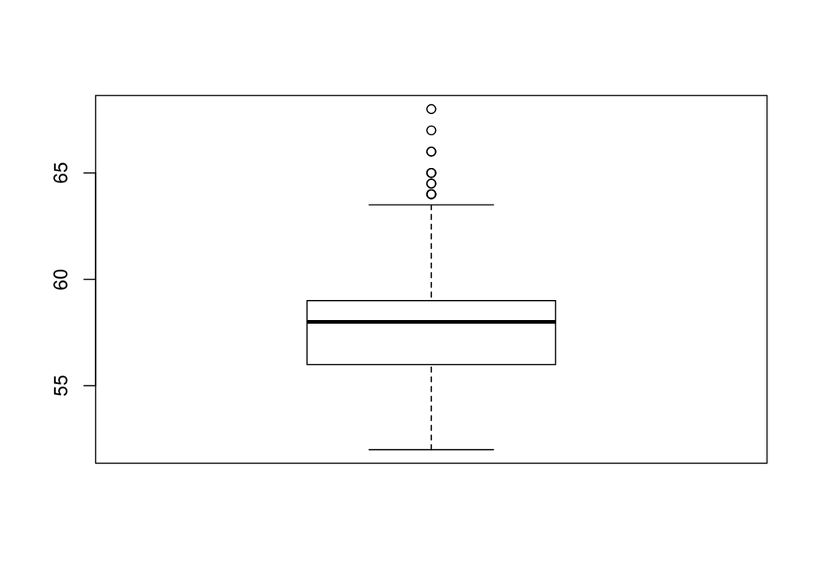

```r
boxplot(sparrows$Wing)
```

The bold line in the middle of the box indicates the median, the lower end of the box is the 25% quartile, the upper end of the box is the 75% quartile. The ‘hinge’ is the 75% quartile minus the 25% quartile. The lines (or whiskers) indicate 1.5 times the size of the hinge. (Note that the interval defined by these lines is not a confidence interval.) Points beyond these lines are (often wrongly) considered to be outliers.

In this case, the boxplot is suggesting to us that there may be at least 6 outliers.

Boxplots provide a summary of the data. As we will discuss in Unit 5, a better approach would be to present the raw data as well. We can use the basic `plot()` function to do this. Use `plot()` to display the wing measurements.

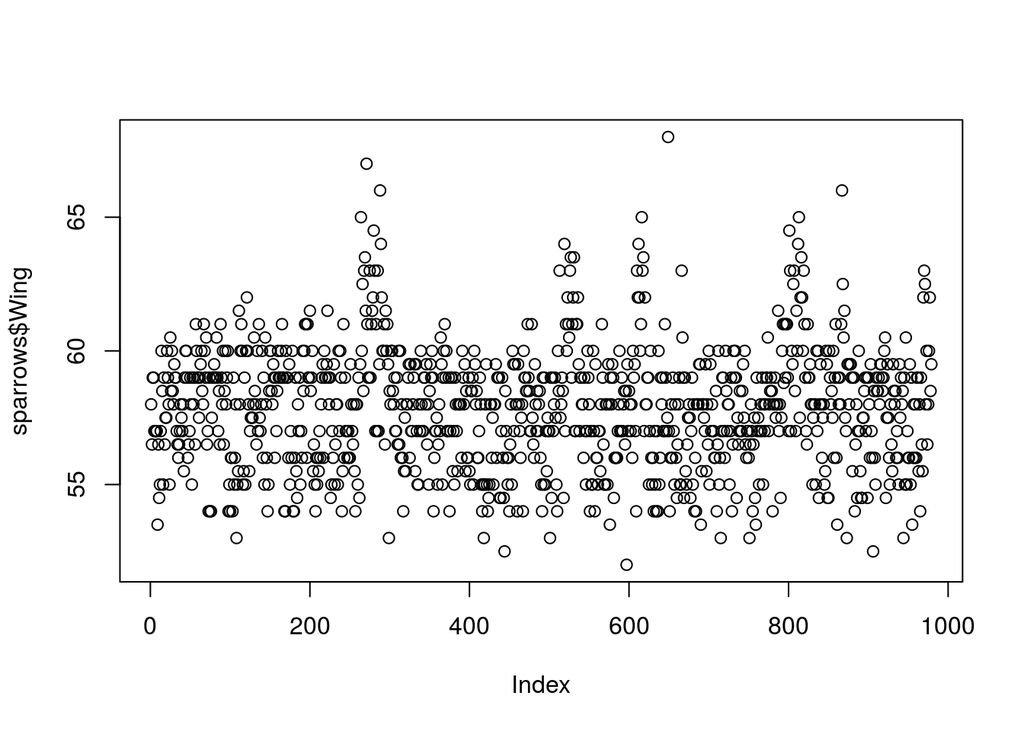

```r
plot(sparrows$Wing)
```

As usual, running `plot()` on a numeric vector creates a plot showing each data point as an open circle, displayed in the order they occur in the vector (indicated by the x-axis, labelled Index).

This plot is a version of the ‘Cleveland dotplot’, the row number (i.e., index) of an observation is plotted vs. the observation value.

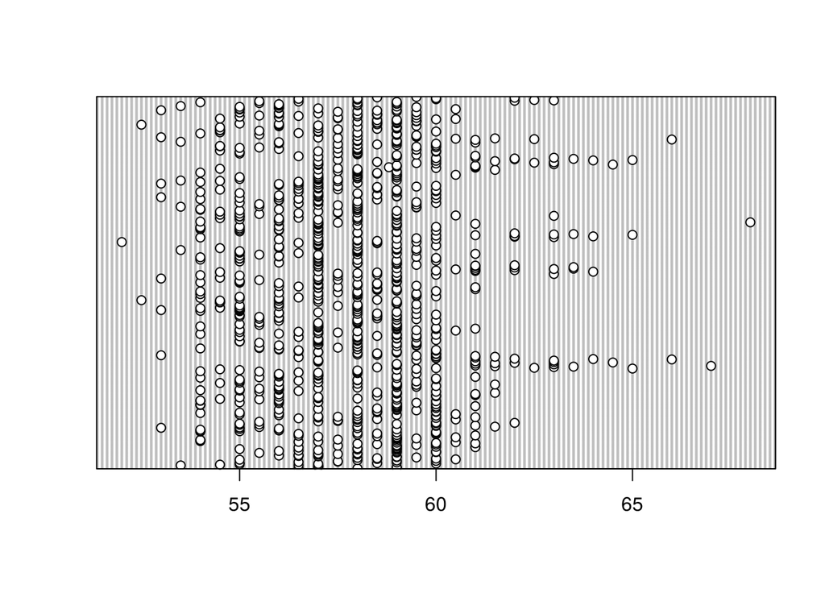

```r
dotchart(sparrows$Wing)
```

Here the function has rotated the plot, compared to before. The data are organised by index on the y-axis and the values are indicated on the x-axis. We also see vertical grey lines that make it easier to compare the horizontal position of each point.

Create a dotchart of the sparrow wing data, grouped by species.

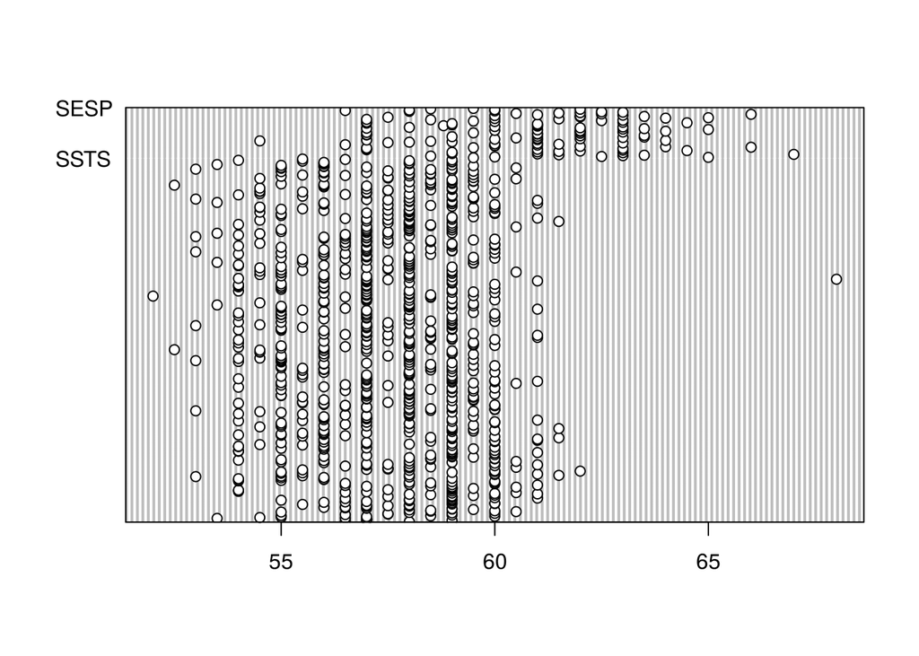

```r
dotchart(sparrows$Wing, group = sparrows$Species)
```

Now we can see that most of the ‘outliers’ in fact belong to the species ‘SESP’ and appear much more within the expected range of the data. There is only one value from the ‘SSTS’ species that appears abnormally high.

What you then do with any outliers depends. If there are no data entry errors, you could check for other explanatory factors, transform the data, or drop the sample with the outlier, depending on the sensitivity of the analysis. Be careful how you treat outliers - ethically removing points of data because they don’t fit your expectation requires strong justification.

## Do we have homogeneity of variance?

Homogeneity of variance is an important assumption in analysis of variance (ANOVA), other regression-related models and some multivariate techniques. Violation of constant variance across groups makes it hard to estimate the standard deviation of the coefficient estimates.

In ANOVA, we can check the variance by making conditional boxplots for each group. Make a boxplot of $Wing conditional on $Species and $Sex. We can do this by writing a formula: sparrows$Wing ~ sparrows$Sex + sparrows$Species. The tilde (~) means ‘as a function of’. Create a plot of boxplots using this formula.

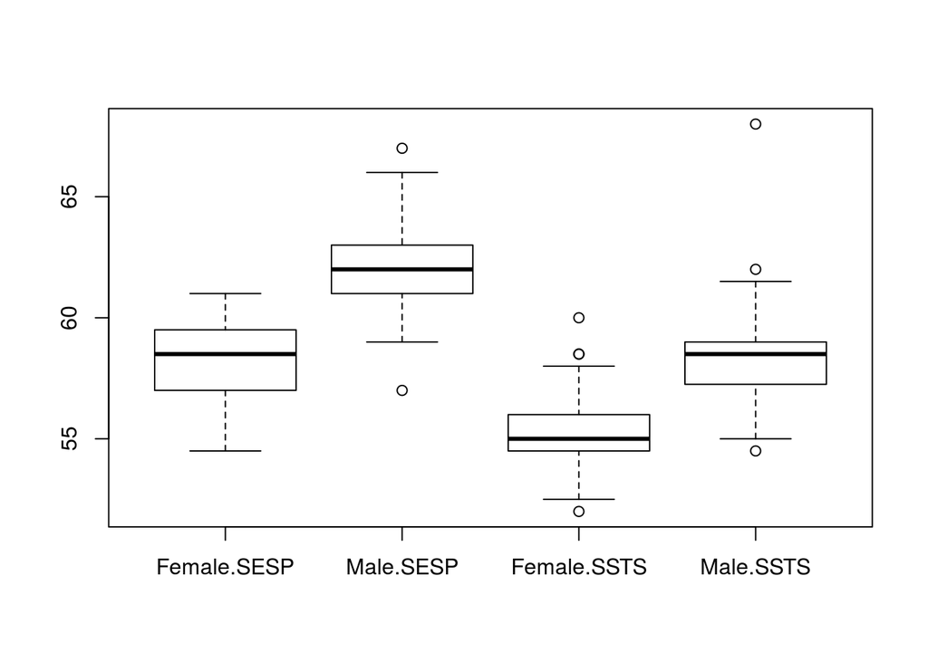

```r
boxplot(sparrows$Wing ~ sparrows$Sex + sparrows$Species)
```

To perform this model as an ANOVA, the variation in the observations from the sexes should be similar, as should the variation in the observations from the species. In this case, there seems to be less variation in females of SSTS than females of SESP. Larger differences would be more worrying.

To verify that variances are homogeneous in regression-type models with continuous predictors, we should use the *residuals* (i.e., the differences between the observed values and the estimated values) of the model. We have loaded a model of sparrow wing length on weight + species. Type ‘m’ to look at the model coefficients.

```r
m
```

```
##
## Call:
## lm(formula = sparrows$Wing ~ sparrows$Weight + sparrows$Species)
##
## Coefficients:
##          (Intercept)       sparrows$Weight  sparrows$SpeciesSSTS
##              43.6014                0.7476               -0.9747
```

Now type ‘str(m)’ to look at the model structure and see how we can extract the residuals.

```r
str(m)
```

```
## List of 13
##  $ coefficients : Named num [1:3] 43.601 0.748 -0.975
##   ..- attr(*, "names")= chr [1:3] "(Intercept)" "sparrows$Weight" "sparrows$SpeciesSSTS"
##  $ residuals    : Named num [1:979] 0.197 0.865 0.673 0.673 -0.43 ...
##   ..- attr(*, "names")= chr [1:979] "1" "2" "3" "4" ...
##  $ effects      : Named num [1:979] -1810.567 47.154 7.991 0.662 -0.448 ...
##   ..- attr(*, "names")= chr [1:979] "(Intercept)" "sparrows$Weight" "sparrows$SpeciesSSTS" "" ...
##  $ rank         : int 3
##  $ fitted.values: Named num [1:979] 57.8 55.6 58.3 58.3 57.4 ...
##   ..- attr(*, "names")= chr [1:979] "1" "2" "3" "4" ...
##  $ assign       : int [1:3] 0 1 2
##  $ qr           :List of 5
##   ..$ qr   : num [1:979, 1:3] -31.289 0.032 0.032 0.032 0.032 ...
##   .. ..- attr(*, "dimnames")=List of 2
##   .. .. ..$ : chr [1:979] "1" "2" "3" "4" ...
##   .. .. ..$ : chr [1:3] "(Intercept)" "sparrows$Weight" "sparrows$SpeciesSSTS"
##   .. ..- attr(*, "assign")= int [1:3] 0 1 2
##   .. ..- attr(*, "contrasts")=List of 1
##   .. .. ..$ sparrows$Species: chr "contr.treatment"
##   ..$ qraux: num [1:3] 1.03 1.05 1.02
##   ..$ pivot: int [1:3] 1 2 3
##   ..$ tol  : num 1e-07
##   ..$ rank : int 3
##   ..- attr(*, "class")= chr "qr"
##  $ df.residual  : int 976
##  $ contrasts    :List of 1
##   ..$ sparrows$Species: chr "contr.treatment"
##  $ xlevels      :List of 1
##   ..$ sparrows$Species: chr [1:2] "SESP" "SSTS"
##  $ call         : language lm(formula = sparrows$Wing ~ sparrows$Weight + sparrows$Species)
##  $ terms        :Classes 'terms', 'formula'  language sparrows$Wing ~ sparrows$Weight + sparrows$Species
##   .. ..- attr(*, "variables")= language list(sparrows$Wing, sparrows$Weight, sparrows$Species)
##   .. ..- attr(*, "factors")= int [1:3, 1:2] 0 1 0 0 0 1
##   .. .. ..- attr(*, "dimnames")=List of 2
##   .. .. .. ..$ : chr [1:3] "sparrows$Wing" "sparrows$Weight" "sparrows$Species"
##   .. .. .. ..$ : chr [1:2] "sparrows$Weight" "sparrows$Species"
##   .. ..- attr(*, "term.labels")= chr [1:2] "sparrows$Weight" "sparrows$Species"
##   .. ..- attr(*, "order")= int [1:2] 1 1
##   .. ..- attr(*, "intercept")= int 1
##   .. ..- attr(*, "response")= int 1
```

[output cut: 8 more lines]

```
##   ..- attr(*, "terms")=Classes 'terms', 'formula'  language sparrows$Wing ~ sparrows$Weight + sparrows$Species
##   .. .. ..- attr(*, "variables")= language list(sparrows$Wing, sparrows$Weight, sparrows$Species)
##   .. .. ..- attr(*, "factors")= int [1:3, 1:2] 0 1 0 0 0 1
##   .. .. .. ..- attr(*, "dimnames")=List of 2
##   .. .. .. .. ..$ : chr [1:3] "sparrows$Wing" "sparrows$Weight" "sparrows$Species"
##   .. .. .. .. ..$ : chr [1:2] "sparrows$Weight" "sparrows$Species"
##   .. .. ..- attr(*, "term.labels")= chr [1:2] "sparrows$Weight" "sparrows$Species"
##   .. .. ..- attr(*, "order")= int [1:2] 1 1
##   .. .. ..- attr(*, "intercept")= int 1
##   .. .. ..- attr(*, "response")= int 1
##   .. .. ..- attr(*, ".Environment")=<environment: R_GlobalEnv>
##   .. .. ..- attr(*, "predvars")= language list(sparrows$Wing, sparrows$Weight, sparrows$Species)
##   .. .. ..- attr(*, "dataClasses")= Named chr [1:3] "numeric" "numeric" "factor"
##   .. .. .. ..- attr(*, "names")= chr [1:3] "sparrows$Wing" "sparrows$Weight" "sparrows$Species"
##  - attr(*, "class")= chr "lm"
```

There is a lot in there! But, scroll up to the top and you will see `$ residuals : Named num [1:979] 0.197 ...`. Extract (subset) this part of m as a vector. Remember that m, the model output, is a list.

```r
m$residuals
```

[output not shown]

[output cut: 337 more lines]

[output not shown]

Now that you can get at the residuals, we can use a similar method to extract the fitted (i.e., predicted) values. Use these two vectors to make a plot of residuals as a function of fitted values of the model m, to check for variation in the variance, within a call to `plot()`. Use the `~` notation as we did in the boxplot for your plot formula.

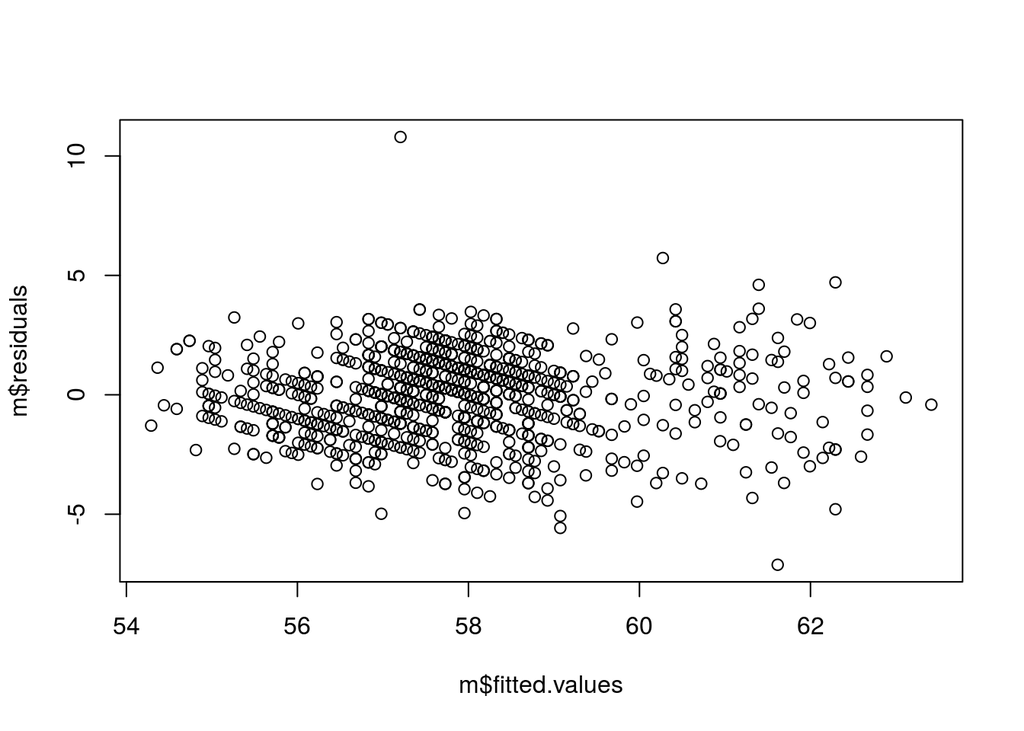

```r
plot(m$residuals ~ m$fitted.values)
```

The residuals look to be ok, there is no great widening or narrowing of the distribution as we move along the x-axis. (There is one large residual up top, though). When assessing equal variance, we want to see a relatively homogenous cloud of points. We don’t want to see any structure in this cloud - the most common is when variance is greater at one end of your data’s range than another, giving a conical shape to your residuals.

For any categorical predictors in the model, we would make boxplots of the residuals conditional on these factors, as above.

For those who really want it, you can run a Bartlett’s test for equality of variances with the function `bartlett.test().

To resolve inhomogenous variance, you either have to transform the response variable, or use an approach that does not require homogeneity of variance (e.g., generalised least squares).

## Are the data normally distributed?

Many statistical techniques assume that the data are normally distributed, including linear regression and t-tests. Violations of normality create problems for determining whether model coefficients are significantly different from zero and for calculating confidence intervals. Normality is not required for estimating the values of the coefficients themselves (although outliers may do …).

We can examine the normality of data by plotting a histogram. Plot a basic histogram of sparrow weight.

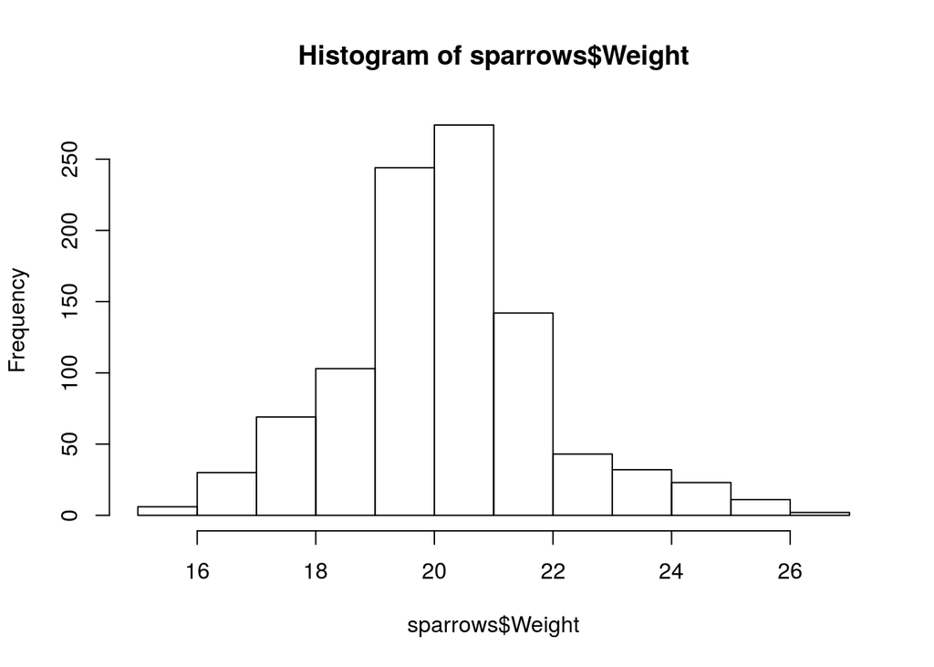

```r
hist(sparrows$Weight)
```

The distribution is slightly skewed, with more lower values than higher values. For a test such as a t-test, all we can do to assess normality is plot the raw data. For a regression, we should again be checking the residuals. Plot a histogram of the residuals from the model ‘m’.

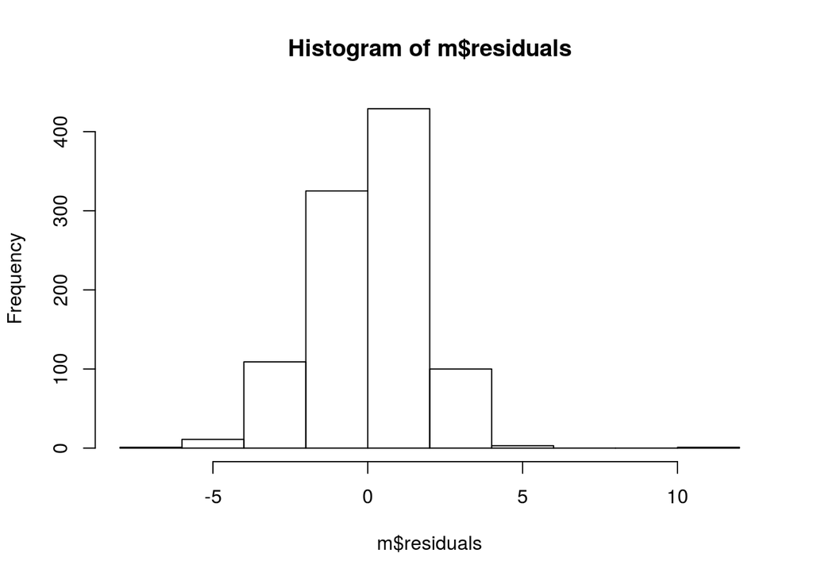

```r
hist(m$residuals)
```

These look better! Less skewed.

Another graphical tool for examining normality is the normal probability plot or normal quantile plot of the residuals. We use the function `qqnorm()` to generate this plot. The residuals should fall more or less along a straight line. Make a qq plot of the residuals from the model m.

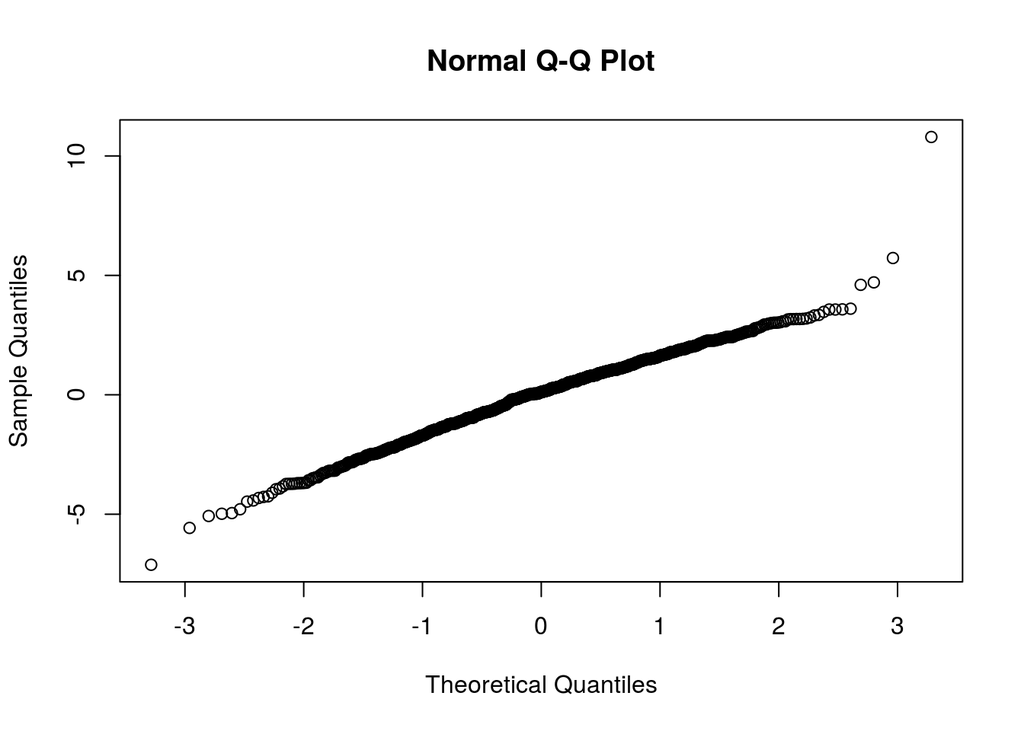

```r
qqnorm(m$residuals)
```

It can be helpful to see a reference diagonal. Add the line by typing qqline(m$residuals).

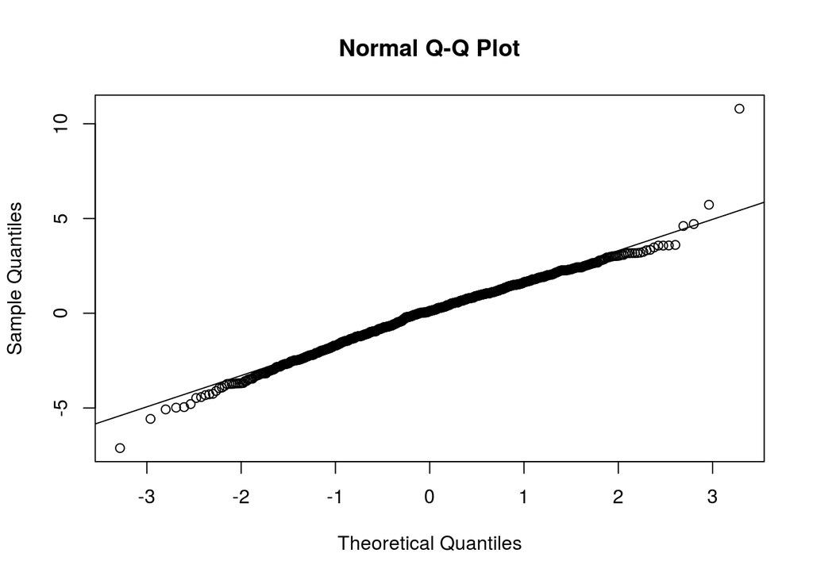

```r
qqnorm(m$residuals)
qqline(m$residuals)
```

A normal distribution is indicated by the points lying close to the diagonal reference line. A bow-shaped pattern of deviations from the diagonal indicates that the residuals have excessive skewness (i.e., they are not symmetrically distributed, with too many large errors in one direction). An S-shaped pattern of deviations indicates that the residuals have excessive kurtosis (i.e., there are either too many or two few large errors in both directions).

If you really need a p-value for your decision, you can use a Shapiro-Wilk test: `shapiro.test(). Run this test on the residuals of our model.

```r
shapiro.test(m$residuals)
```

```
##
##  Shapiro-Wilk normality test
##
## data:  m$residuals
## W = 0.98375, p-value = 5.661e-09
```

The p-value in this case indicates that our distribution is significantly different from a normal distribution. Realistically, this will nearly always be the case, making the test somewhat unhelpful. Examining model fit through residuals will give you a better idea as to whether the distribution of your data is a problem.

For further reading on the issue of statistical tests of normality, see Zuur et al. 2010, Laasa 2009, and this [link](https://stats.stackexchange.com/questions/90697/is-shapiro-wilk-the-best-normality-test-why-might-it-be-better-than-other-tests?noredirect=1&lq=1). As you may realise, real data with perfect Normal errors are extremely rare.

## Are there lots of zeros in the data?

When working with count data (e.g., number of bugs on a leaf), it is common to have zeros. In some cases, one can have a lot of zeros. Such ‘zero-inflated’ data is problematical to analyze, and will require either a two-step approach first modelling the zeros and non-zeros using a binomial generalized linear model, and then only the non-zeros likely with a Poisson glm; or using a zero-inflated glm which essentially does these two steps at once. Much of this will make more sense when we start modeling associations in Unit 4.

## Is there collinearity among the covariates?

Collinearity is the existence of correlation between covariates (the various predictor variables in your model). For example, weight and height are often tightly correlated, as are levels of soil nutrients. If collinear variables are all in the model, it is hard for the model to determine which variables are significant.

We can check for collinearity quickly with the `plot()` function again. Running `plot()` on a dataframe will generate a matrix of small plots, with each variable plotted against each other variable. The `pairs()` function does a similar thing. Run `plot()` on the sparrow dataset.

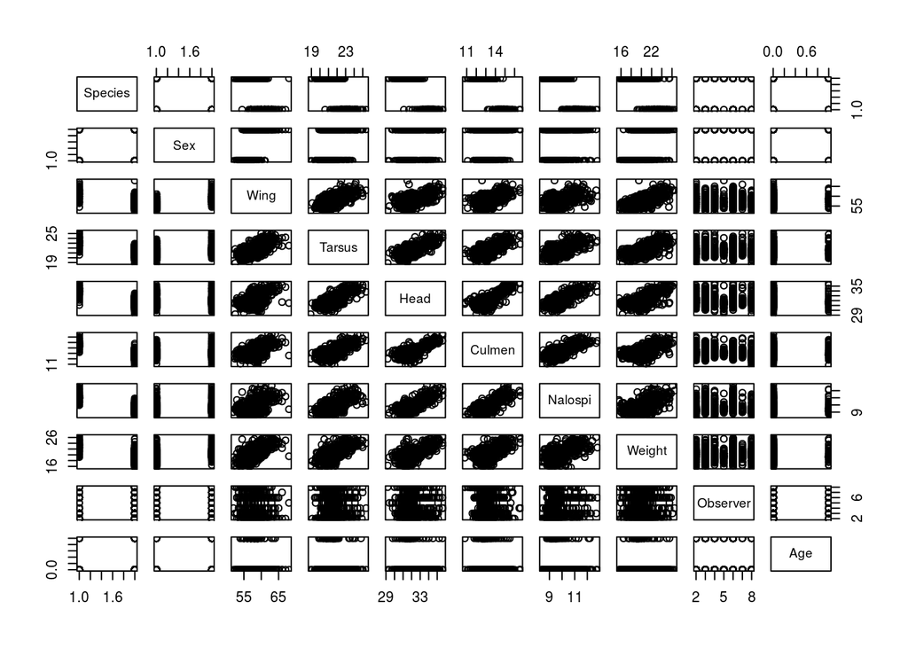

```r
plot(sparrows)
```

You may need to expand the plotting window to interpret the output. Collinearity will show itself as an obvious relationship between two predictors. In this data set, nearly all of the anatomical variables are collinear, which makes sense. Because of this, you would need to take caution using more than one of these variables as predictors in a model, as they represent essentially the same thing (overall body size).

## Are observations of the response variable independent?

A critical assumption of most statistical techniques is that observations are independent of one another. This assumption means that the value of any one data point is not influenced by the values of other data points, after the effects of the predictor variables have been taken into account.

What this means in practice, is that for data that we *know* are likely to be highly auto-correlated, such as time-series, repeated measures, or data with strong spatial structure such as tree growth or survival in a plot, we may or may not need to account for this structure in the model.

Auto-correlation refers to the tendency for observations close in space or time to be similar (i.e. to be correlated with one another).

It may be that the predictors we have in the model account for the auto-correlation and we do not need a explicit spatial or temporal model.

As with Normality and heterogeneity of variance, we can check the residuals of the model for evidence of autocorrelation in space or time (or phylogeny, or …).

Great, now you have some idea of how to explore data and test the assumptions of various statistical approaches. See the links on the Resources page for more background and more advanced techniques.

Please submit the log of this lesson to Google Forms so that Simon may evaluate your progress.